# Extra practice: General Linear Models

# Add-on packages

Did you use any add-on packages when generating your answers? If so, load them in the chunk below.

```r
library(tidyverse)
```

# Tasks 1-4: The `iris` dataset

There is a built-in dataset called `iris` that has measurements of different parts of flowers. (See `?iris` for information about the dataset.)

## Task 1

Use ggplot2 to make a scatterplot that visualizes the relationship between sepal length (horizontal axis) and petal width (vertical axis).

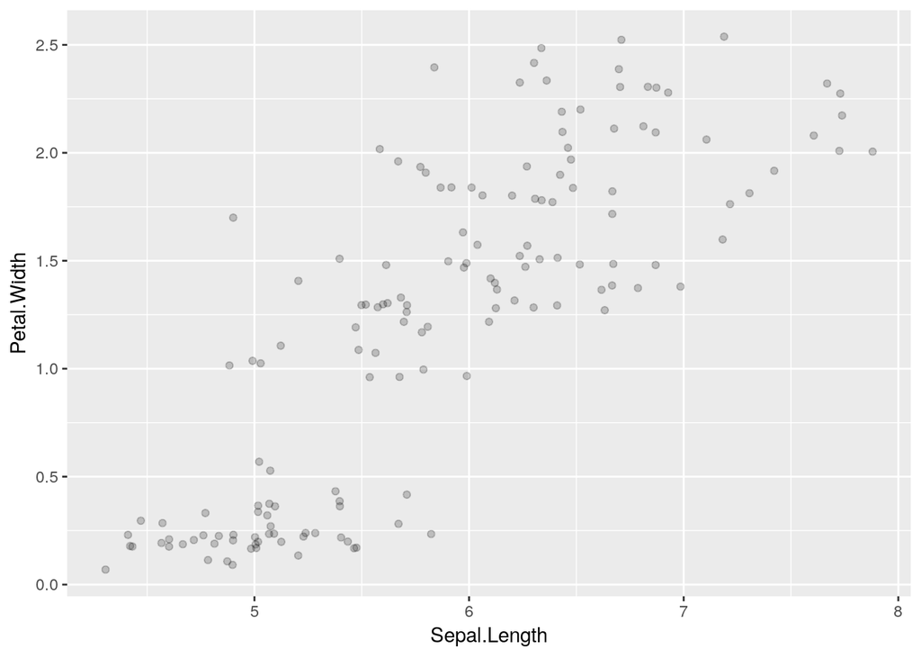

```r
ggplot(iris, aes(Sepal.Length, Petal.Width)) +
  geom_jitter(alpha = .2) # overplotting! watch out!
```

## Task 2

Run a regression model that predicts the petal width from the sepal length, and store the model object in the variable `iris_mod`. End the block by printing out the summary of the model.

```r
iris_mod <- lm(Petal.Width ~ Sepal.Length, iris)

# TODO: print out the model summary
summary(iris_mod)
```

```
##
## Call:
## lm(formula = Petal.Width ~ Sepal.Length, data = iris)
##
## Residuals:
##      Min       1Q   Median       3Q      Max
## -0.96671 -0.35936 -0.01787  0.28388  1.23329
##
## Coefficients:
##              Estimate Std. Error t value Pr(>|t|)
## (Intercept)  -3.20022    0.25689  -12.46   <2e-16 ***
## Sepal.Length  0.75292    0.04353   17.30   <2e-16 ***
## ---
## Signif. codes:  0 '***' 0.001 '**' 0.01 '*' 0.05 '.' 0.1 ' ' 1
##
## Residual standard error: 0.44 on 148 degrees of freedom
## Multiple R-squared:  0.669,  Adjusted R-squared:  0.6668
## F-statistic: 299.2 on 1 and 148 DF,  p-value: < 2.2e-16
```

## Task 3

Make a histogram of the residuals of the model using ggplot2. (HINT: you may need to put the residuals into a table)

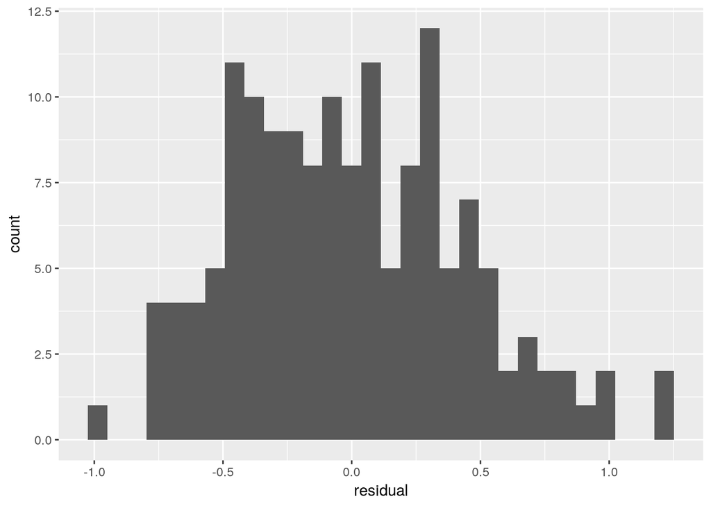

```r
ggplot(tibble(residual = residuals(iris_mod)), aes(residual)) +
  geom_histogram()
```

## Task 4

Write code to predict the petal width for two plants, the first with a sepal length of 5.25cm, and the second with a sepal length of 6.3cm. Store the vector of predictions in the variable `iris_pred`.

```r
iris_pred <- predict(iris_mod, tibble(Sepal.Length = c(5.25, 6.3)))

# print them
iris_pred
```

```
##         1         2
## 0.7526022 1.5431657
```

# Simulating data from the linear model

## Task 5

*NOTE: You can knit this file to html to see formatted versions of the equations below (which are enclosed in `$` characters); alternatively, if you find it easier, you can hover your mouse pointer over the `$` in the code equations to see the formatted versions.*

Write code to randomly generate 10 Y values from a simple linear regression model with an intercept of 3 and a slope of -7. Recall the form of the linear model:

$Y_i = \beta_0 + \beta_1 X_i + e_i$

The residuals ($e_i$s) are drawn from a normal distribution with mean 0 and variance $\sigma^2 = 4$, and $X$ is the vector of integer values from 1 to 10. Store the 10 observations in the variable `Yi` below. (NOTE: the standard deviation is the *square root* of the variance, i.e. $\sigma$; `rnorm()` takes the standard deviation, not the variance, as its third argument).

```r
x <- 1:10
err <- rnorm(10, sd = 2)
Yi <- 3 - 7 * x + err

# print Yi
Yi
```

```
##  [1]  -3.535761  -9.007200 -17.938710 -25.647394 -35.984147 -36.451994
##  [7] -42.896233 -54.699763 -62.737743 -64.578007
```